# Ethics Project

Sam Waller 3/2/2020

Introduction

I studied whether or not the addition of the Rooney Rule has helped to solve the lack of diversity among NFL Head Coaches. The Rooney Rule was an intiative created in 2003 and named after long time Pittsburgh Steelers executive Dan Rooney who was a chairman on the league’s diversity committee. The rule requires that one minority candidate be interview for an open head coaching position. Over the years many have question the effectiveness of the rule, which led to a change in 2018 that required teams to interview a minority candidate that is not employed within their organization. In 2019, TIDES, The Institute for Diverisity and Ethics in Sports, published a report and gave the NFL a D+ for diversity among head coaches due to a decrease in minority head coaches to its lowest figure (4 coaches) since 2003 when the rule was first introduced. In this study, I will identify one of the biggest factor that causes the lack of minority coaches, and I will give my opinion on how the NFL may fix their problem. In order to look at the data and create visializations, I downloaded the packages tidyverse and readr.

Load Tidyverse and Readr

```r
library(tidyverse)
library(readr)
```

Load Data

```r
Ethics_Project_Stat_Sheet_Programming_Coaches_Data<-read.csv(url("https://raw.githubusercontent.com/samuelwaller88/NFL-Coaching-Hiring-Practices/master/Ethics%20Project%20Stat%20Sheet%20-%20Programming%20Coaches%20Data.csv"))


Ethics_Project_Stat_Sheet_Programming_Coaches_Data_1<-read.csv(url("https://raw.githubusercontent.com/samuelwaller88/NFL-Coaching-Hiring-Practices/master/Ethics%20Project%20Stat%20Sheet%20-%20Programming%20Coaches%20Data%20(1).csv"))


Ethics_Project_Stat_Sheet_Programming_Coaches_Data_2<-read.csv(url("https://raw.githubusercontent.com/samuelwaller88/NFL-Coaching-Hiring-Practices/master/Ethics%20Project%20Stat%20Sheet%20-%20Programming%20Coaches%20Data%202.csv"))


Ethics_Project_Stat_Sheet_Programming_Coaches_Data_3<-read.csv(url("https://raw.githubusercontent.com/samuelwaller88/NFL-Coaching-Hiring-Practices/master/Ethics%20Project%20Stat%20Sheet%20-%20Programming%20Coaches%20Data%203.csv"))


Ethics_Project_Stat_Sheet_Programming_Overall_Player_Data<-read.csv(url("https://raw.githubusercontent.com/samuelwaller88/NFL-Coaching-Hiring-Practices/master/Ethics%20Project%20Stat%20Sheet%20-%20Programming%20Overall%20Player%20Data.csv"))


Ethics_Project_Stat_Sheet_Programming_Overall_Player_Data_2<-read.csv(url("https://raw.githubusercontent.com/samuelwaller88/NFL-Coaching-Hiring-Practices/master/Ethics%20Project%20Stat%20Sheet%20-%20Programming%20Overall%20Player%20Data%202.csv"))


Ethics_Project_Stat_Sheet_Programming_Overall_Player_Data_3<-read.csv(url("https://raw.githubusercontent.com/samuelwaller88/NFL-Coaching-Hiring-Practices/master/Ethics%20Project%20Stat%20Sheet%20-%20Programming%20Overall%20Player%20Data%203.csv"))


Ethics_Project_Stat_Sheet_Programming_Player_Data_by_Position<-read.csv(url("https://raw.githubusercontent.com/samuelwaller88/NFL-Coaching-Hiring-Practices/master/Ethics%20Project%20Stat%20Sheet%20-%20Programming%20Player%20Data%20by%20Position.csv"))


Ethics_Project_Stat_Sheet_Programming_Captian_Data<-read.csv(url("https://raw.githubusercontent.com/samuelwaller88/NFL-Coaching-Hiring-Practices/master/Ethics%20Project%20Stat%20Sheet%20-%20Programming%20Captian%20Data.csv"))


Ethics_Project_Stat_Sheet_Coaching_Hiring_Practices<-read.csv(url("https://raw.githubusercontent.com/samuelwaller88/NFL-Coaching-Hiring-Practices/master/Ethics%20Project%20Stat%20Sheet%20-%20Coaching%20Hiring%20Practices.csv"))


Ethics_Project_Stat_Sheet_Offense_Defense_Coordinator_Numbers<-read.csv(url("https://raw.githubusercontent.com/samuelwaller88/NFL-Coaching-Hiring-Practices/master/Ethics%20Project%20Stat%20Sheet%20-%20Offense_Defense%20Coordinator%20Numbers.csv"))
```

Coaching Hiring Data

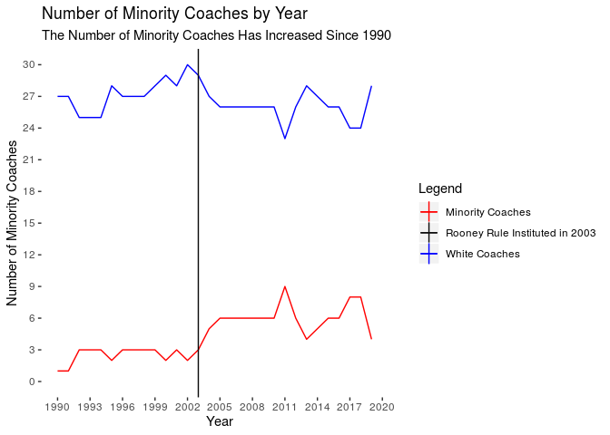

```r
minority_white_color <- c("Minority Coaches" = "red", "White Coaches" = "blue","Rooney Rule Instituted in 2003"="gray4")

Number_Of_Coaches_By_Year<- Ethics_Project_Stat_Sheet_Programming_Coaches_Data_3 %>%
  ggplot(aes(x=Year)) +
  geom_line(aes(y=Total_Minority_Coaches, color="Minority Coaches"),linetype = "solid")+
  geom_line(aes(y=Total_White_Coaches, color="White Coaches"), linetype = "solid")+
  geom_vline(aes(xintercept =2003, color="Rooney Rule Instituted in 2003"))+
     scale_x_continuous(limits = c(1990,2020),
        breaks = seq(1990, 2020, 3)) +
     scale_y_continuous(limits = c(0,30),
        breaks = seq(0, 30, 3)) +
  scale_color_manual(values=minority_white_color)+
    labs( x="Year", y="Number of Minority Coaches", title="Number of Minority Coaches by Year", subtitle="The Number of Minority Coaches Has Increased Since 1990", color="Legend" )+
  theme(panel.grid.major = element_blank(), panel.grid.minor = element_blank(), panel.background = element_blank())
Number_Of_Coaches_By_Year
```

```r
Number_Of_Minority_Coaches_By_Year_ss<-Ethics_Project_Stat_Sheet_Programming_Coaches_Data%>%
   summarize(avg = mean(Total_Minority_Coaches), med = median(Total_Minority_Coaches),
                    standard_dev = sd(Total_Minority_Coaches),
                    iqr = IQR(Total_Minority_Coaches))
Number_Of_Minority_Coaches_By_Year_ss
```

```
##   avg med standard_dev iqr
## 1 4.4   4     2.110728   3
```

```r
Number_Of_White_Coaches_By_Year_ss<-Ethics_Project_Stat_Sheet_Programming_Coaches_Data_3%>%
   summarize(avg = mean(Total_White_Coaches), med = median(Total_White_Coaches),
                    standard_dev = sd(Total_White_Coaches),
                    iqr = IQR(Total_White_Coaches))
Number_Of_White_Coaches_By_Year_ss
```

```
##        avg  med standard_dev  iqr
## 1 26.56667 26.5     1.568732 1.75
```

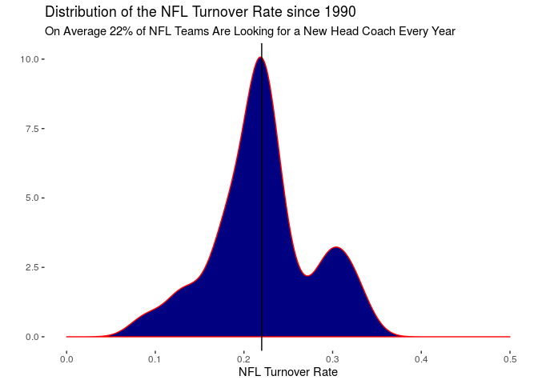

```r
Turnover_Rate_hist<-Ethics_Project_Stat_Sheet_Programming_Coaches_Data_2 %>%
            ggplot(aes(x = Turnover_Rate)) +
            geom_density(fill="navyblue", color="red") +
            labs(x = "NFL Turnover Rate", y = "",
                 title = "Distribution of the NFL Turnover Rate since 1990", subtitle = "On Average 22% of NFL Teams Are Looking for a New Head Coach Every Year")  +
        scale_x_continuous(limits = c(0,0.5),
          breaks = seq(0, 0.5, .1)) +
        geom_vline(aes(xintercept = median(Turnover_Rate)), color = "black")  +
        theme(panel.grid.major = element_blank(), panel.grid.minor = element_blank(), panel.background = element_blank())
Turnover_Rate_hist
```

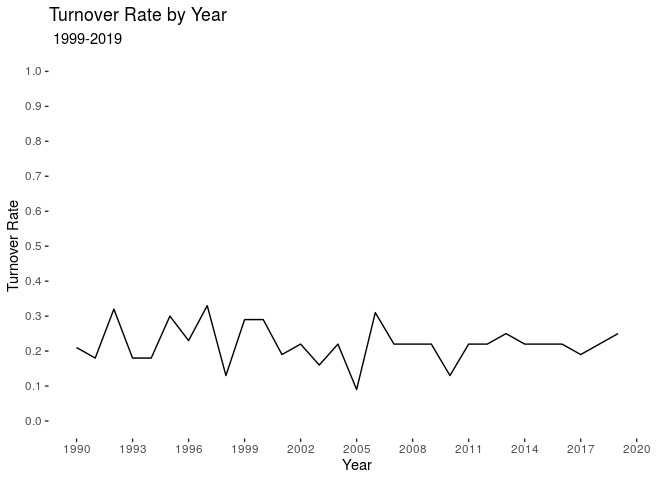

```r
Turnover_Rate_by_Year<-Ethics_Project_Stat_Sheet_Programming_Coaches_Data_3%>%
  ggplot(aes(x=Year)) +
  geom_line(aes(y = Turnover_Rate), linetype="solid")+
  scale_x_continuous(limits = c(1990,2020),
        breaks = seq(1990, 2020, 3)) +
     scale_y_continuous(limits = c(0,1),
        breaks = seq(0, 1, .1)) +
    labs( x="Year", y="Turnover Rate", title="Turnover Rate by Year", subtitle=" 1999-2019")+
  theme(panel.grid.major = element_blank(), panel.grid.minor = element_blank(), panel.background = element_blank())
Turnover_Rate_by_Year
```

```r
Turnover_Rate_ss<-Ethics_Project_Stat_Sheet_Programming_Coaches_Data_2%>%
   summarize(avg = mean(Turnover_Rate), med = median(Turnover_Rate),
                    standard_dev = sd(Turnover_Rate),
                    iqr = IQR(Turnover_Rate))
Turnover_Rate_ss
```

```
##     avg  med standard_dev   iqr
## 1 0.221 0.22   0.05622308 0.055
```

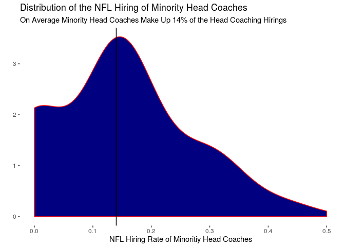

```r
Minority_Hiring_Rate_hist<-Ethics_Project_Stat_Sheet_Programming_Coaches_Data_2 %>%
            ggplot(aes(x = Percent_of_Total_Hiring)) +
      geom_density(fill="navyblue", color="red") +
            labs(x = "NFL Hiring Rate of Minoritiy Head Coaches", y = "",
                 title = "Distribution of the NFL Hiring of Minority Head Coaches", subtitle = "On Average Minority Head Coaches Make Up 14% of the Head Coaching Hirings")  +
        scale_x_continuous(limits = c(0,0.5),
          breaks = seq(0, 0.5, .1)) +
        geom_vline(aes(xintercept = median(Percent_of_Total_Hiring)), color = "black")  +
        theme(panel.grid.major = element_blank(), panel.grid.minor = element_blank(), panel.background = element_blank())
Minority_Hiring_Rate_hist
```

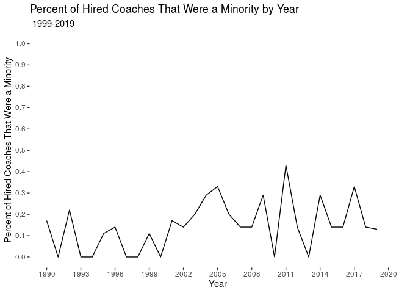

```r
Minority_Percent_of_Total_Hiring_by_Year<-Ethics_Project_Stat_Sheet_Programming_Coaches_Data_3%>%
  ggplot(aes(x=Year)) +
  geom_line(aes(y = Percent_of_Total_Hiring), linetype="solid")+
  scale_x_continuous(limits = c(1990,2020),
        breaks = seq(1990, 2020, 3)) +
     scale_y_continuous(limits = c(0,1),
        breaks = seq(0, 1, .1)) +
    labs( x="Year", y="Percent of Hired Coaches That Were a Minority", title="Percent of Hired Coaches That Were a Minority by Year", subtitle=" 1999-2019")+
  theme(panel.grid.major = element_blank(), panel.grid.minor = element_blank(), panel.background = element_blank())
Minority_Percent_of_Total_Hiring_by_Year
```

```r
Minority_Hiring_Rate_ss<-Ethics_Project_Stat_Sheet_Programming_Coaches_Data_2%>%
   summarize(avg = mean(Percent_of_Total_Hiring), med = median(Percent_of_Total_Hiring),
                    standard_dev = sd(Percent_of_Total_Hiring),
                    iqr = IQR(Percent_of_Total_Hiring))
Minority_Hiring_Rate_ss
```

```
##         avg  med standard_dev    iqr
## 1 0.1463333 0.14    0.1169581 0.1725
```

Overall Player Data

[output not shown]

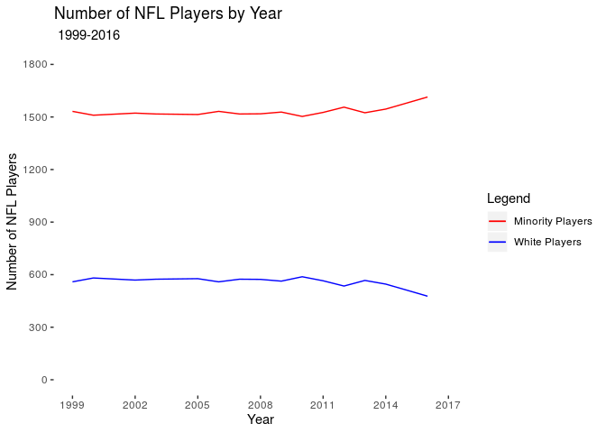

```r
colors <- c("Minority Players" = "red", "White Players" = "blue")

ggplot(Ethics_Project_Stat_Sheet_Programming_Overall_Player_Data_3, aes(x=Year)) +
   scale_color_manual(values = colors)+
  geom_line(aes(y = Number_of_White_Players, color = "White Players"), linetype="solid") +
  geom_line(aes(y = Number_of_Minority_Players,color="Minority Players"), linetype="solid")+
  scale_color_manual(values=colors)+
  scale_x_continuous(limits = c(1999,2017),
        breaks = seq(1999, 2017, 3)) +
     scale_y_continuous(limits = c(0,1800),
        breaks = seq(0, 1800, 300)) +
    labs( x="Year", y="Number of NFL Players", title="Number of NFL Players by Year", subtitle=" 1999-2016", color = "Legend")+
  theme(panel.grid.major = element_blank(), panel.grid.minor = element_blank(), panel.background = element_blank())
```

```r
Minority_Players_By_Year_ss<-Ethics_Project_Stat_Sheet_Programming_Overall_Player_Data_3%>%
   summarize(avg = mean(Number_of_Minority_Players), med = median(Number_of_Minority_Players),
                    standard_dev = sd(Number_of_Minority_Players),
                    iqr = IQR(Number_of_Minority_Players))
Minority_Players_By_Year_ss
```

```
##        avg  med standard_dev iqr
## 1 1530.533 1524     26.65619  15
```

```r
White_Players_By_Year_ss<-Ethics_Project_Stat_Sheet_Programming_Overall_Player_Data_3%>%
   summarize(avg = mean(Number_of_White_Players), med = median(Number_of_White_Players),
                    standard_dev = sd(Number_of_White_Players),
                    iqr = IQR(Number_of_White_Players))
White_Players_By_Year_ss
```

```
##        avg med standard_dev iqr
## 1 560.4667 567     26.65619  15
```

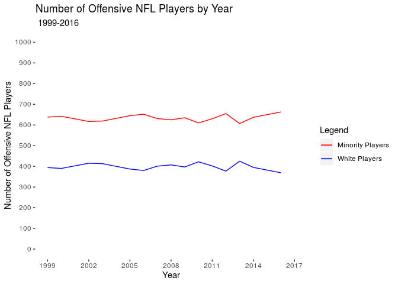

```r
ggplot(Ethics_Project_Stat_Sheet_Programming_Overall_Player_Data_3, aes(x=Year)) +
   scale_color_manual(values = colors)+
  geom_line(aes(y = White_Players_on_Offense, color = "White Players"), linetype="solid") +
  geom_line(aes(y = Minortity_Players_on_Offense,color="Minority Players"), linetype="solid")+
  scale_x_continuous(limits = c(1999,2017),
        breaks = seq(1999, 2017, 3)) +
     scale_y_continuous(limits = c(0,1000),
        breaks = seq(0, 1000, 100)) +
    labs( x="Year", y="Number of Offensive NFL Players", title="Number of Offensive NFL Players by Year", subtitle=" 1999-2016", color = "Legend")+
  theme(panel.grid.major = element_blank(), panel.grid.minor = element_blank(), panel.background = element_blank())
```

```r
Minority_Offensive_Players_By_Year_ss<-Ethics_Project_Stat_Sheet_Programming_Overall_Player_Data_3%>%
   summarize(avg = mean(Minortity_Players_on_Offense), med = median(Minortity_Players_on_Offense),
                    standard_dev = sd(Minortity_Players_on_Offense),
                    iqr = IQR(Minortity_Players_on_Offense))
Minority_Offensive_Players_By_Year_ss
```

```
##        avg med standard_dev  iqr
## 1 633.7333 635     16.34654 21.5
```

```r
White_Offensive_Players_By_Year_ss<-Ethics_Project_Stat_Sheet_Programming_Overall_Player_Data_3%>%
   summarize(avg = mean(White_Players_on_Offense), med = median(White_Players_on_Offense),
                    standard_dev = sd(White_Players_on_Offense),
                    iqr = IQR(White_Players_on_Offense))
White_Offensive_Players_By_Year_ss
```

```
##        avg med standard_dev  iqr
## 1 398.2667 397     16.34654 21.5
```

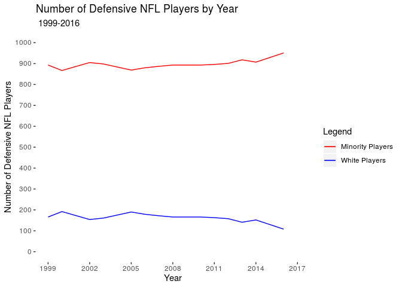

```r
ggplot(Ethics_Project_Stat_Sheet_Programming_Overall_Player_Data_3, aes(x=Year)) +
   scale_color_manual(values = colors)+
  geom_line(aes(y = White_Players_on_Defense, color = "White Players"), linetype="solid") +
  geom_line(aes(y = Minority_Players_on_Defense,color="Minority Players"), linetype="solid")+
  scale_x_continuous(limits = c(1999,2017),
        breaks = seq(1999, 2017, 3)) +
     scale_y_continuous(limits = c(0,1000),
        breaks = seq(0, 1000, 100)) +
    labs( x="Year", y="Number of Defensive NFL Players", title="Number of Defensive NFL Players by Year", subtitle=" 1999-2016", color = "Legend")+
  theme(panel.grid.major = element_blank(), panel.grid.minor = element_blank(), panel.background = element_blank())
```

```r
Minority_Defensive_Players_By_Year_ss<-Ethics_Project_Stat_Sheet_Programming_Overall_Player_Data_3%>%
   summarize(avg = mean(Minority_Players_on_Defense), med = median(Minority_Players_on_Defense),
                    standard_dev = sd(Minority_Players_on_Defense),
                    iqr = IQR(Minority_Players_on_Defense))
Minority_Defensive_Players_By_Year_ss
```

```
##        avg med standard_dev iqr
## 1 896.7333 893     20.13336  13
```

```r
White_Defensive_Players_By_Year_ss<-Ethics_Project_Stat_Sheet_Programming_Overall_Player_Data_3%>%
   summarize(avg = mean(White_Players_on_Defense), med = median(White_Players_on_Defense),
                    standard_dev = sd(White_Players_on_Defense),
                    iqr = IQR(White_Players_on_Defense))
White_Defensive_Players_By_Year_ss
```

```
##        avg med standard_dev iqr
## 1 162.2667 166     20.13336  13
```

Individual Player Data

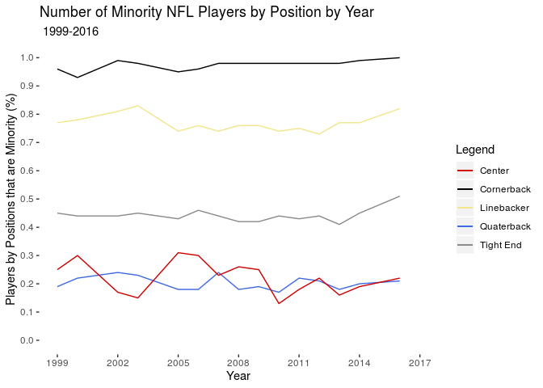

```r
colors1 <- c("Quaterback" = "royalblue", "Center" = "red3", "Tight End"="snow4","Cornerback"="black", "Linebacker"="khaki")
ggplot(Ethics_Project_Stat_Sheet_Programming_Player_Data_by_Position, aes(x=Year)) +
   scale_color_manual(values = colors1)+
  geom_line(aes(y = QB, color = "Quaterback"), linetype="solid") +
  geom_line(aes(y = C,color="Center"), linetype="solid")+
  geom_line(aes(y = TE, color = "Tight End"), linetype="solid") +
  geom_line(aes(y = CB,color="Cornerback"), linetype="solid")+
  geom_line(aes(y = LB, color = "Linebacker"), linetype="solid") +
  scale_x_continuous(limits = c(1999,2017),
        breaks = seq(1999, 2017, 3)) +
     scale_y_continuous(limits = c(0,1),
        breaks = seq(0, 1, 0.1)) +
    labs( x="Year", y="Players by Positions that are Minority (%)", title="Number of Minority NFL Players by Position by Year", subtitle=" 1999-2016", color = "Legend")+
    theme(panel.grid.major = element_blank(), panel.grid.minor = element_blank(), panel.background = element_blank())
```

```r
Number_Of_Minority_QB_By_Year_ss<-Ethics_Project_Stat_Sheet_Programming_Player_Data_by_Position%>%
   summarize(avg = mean(QB), med = median(QB),
                    standard_dev = sd(QB),
                    iqr = IQR(QB))
Number_Of_Minority_QB_By_Year_ss
```

```
##         avg med standard_dev  iqr
## 1 0.2026667 0.2   0.02344192 0.04
```

```r
Number_Of_Minority_C_By_Year_ss<-Ethics_Project_Stat_Sheet_Programming_Player_Data_by_Position%>%
   summarize(avg = mean(C), med = median(C),
                    standard_dev = sd(C),
                    iqr = IQR(C))
Number_Of_Minority_C_By_Year_ss
```

```
##         avg  med standard_dev  iqr
## 1 0.2213333 0.22   0.05730453 0.08
```

```r
Number_Of_Minority_TE_By_Year_ss<-Ethics_Project_Stat_Sheet_Programming_Player_Data_by_Position%>%
   summarize(avg = mean(TE), med = median(TE),
                    standard_dev = sd(TE),
                    iqr = IQR(TE))
Number_Of_Minority_TE_By_Year_ss
```

```
##     avg  med standard_dev  iqr
## 1 0.442 0.44   0.02305273 0.02
```

```r
Number_Of_Minority_CB_By_Year_ss<-Ethics_Project_Stat_Sheet_Programming_Player_Data_by_Position%>%
   summarize(avg = mean(CB), med = median(CB),
                    standard_dev = sd(CB),
                    iqr = IQR(CB))
Number_Of_Minority_CB_By_Year_ss
```

```
##         avg  med standard_dev  iqr
## 1 0.9746667 0.98    0.0176743 0.01
```

```r
Number_Of_Minority_LB_By_Year_ss<-Ethics_Project_Stat_Sheet_Programming_Player_Data_by_Position%>%
   summarize(avg = mean(LB), med = median(LB),
                    standard_dev = sd(LB),
                    iqr = IQR(LB))
Number_Of_Minority_LB_By_Year_ss
```

```
##         avg  med standard_dev  iqr
## 1 0.7686667 0.76   0.03020564 0.03
```

I looked at the proportion of minority player over 5 positions between 1999 and 2016. All of the distributions were roughly evenly distributated and with minimal standard deviation. On offense, the quarterback remained near constant around the average of 0.2 players were a minority. Likewise, center remained around the median of 0.22. The first position of were there was a change in the proportion of minorities was the tight end position. In 1999, 45% of tights end were minority. However in 2016, that percentage increased to 51%. Additionally, this increase began in 2013, so this one position that helped to increase the amount of minority players between 2013 and 2016. On defense, the position that most helped the trend of increasing minority players in the NFL was linebacker position. From 2012 to 2016, the number of minority players increased from 73% of players to 82% of the players. Lastly, I looked at minority cornerbacks who by 2016 made up 100% of the cornerback group. With this data, we can see that there are position where minority are well represented (Cornerback, Linebacker, Tight End) while there other position of offense where minorities are poorly represented (Quarterback and Center).

2019 NFL Captain Data

```r
Captain_Prop_Table_Setup<- Ethics_Project_Stat_Sheet_Programming_Captian_Data %>%
            group_by(Offense_Defense, Minority) %>%
            summarize(number = n()) %>%
            spread(Offense_Defense, number)
Captain_Prop_Table_Setup

prop.table(table(Ethics_Project_Stat_Sheet_Programming_Captian_Data$Offense_Defense, Ethics_Project_Stat_Sheet_Programming_Captian_Data$Minority)) %>%
  round(4)
```

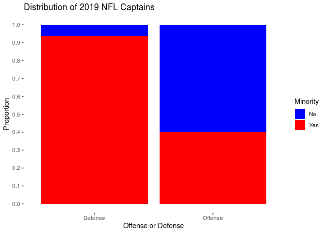

```r
Captain_100_Percent_Stacked <- Ethics_Project_Stat_Sheet_Programming_Captian_Data %>%
            ggplot(aes(Offense_Defense, fill = Minority)) +
            geom_bar(position = "fill") +
            labs(x = "Offense or Defense", y = "Proportion", fill = "Minority", title = "Distribution of 2019 NFL Captains")+
          scale_fill_manual(values=c("Blue", "Red"))+
          scale_y_continuous(limits = c(0,1),
                    breaks = seq(0, 1, 0.1)) +
        theme(panel.grid.major = element_blank(), panel.grid.minor = element_blank(), panel.background = element_blank())
Captain_100_Percent_Stacked
```

The last piece of player data I analized the was proportion of minorities players that were voted team captain. In 2019 there were 128 offensive and defensive captains over 29 teams as the Bears, Broncos, and Ravens were the only teams that didn’t have official captains during the 2019 season. There were roughly the same amount of offensive and defensive captains with offense having two more captains. Of the 63 defensive captains, 59 of the captains were minorities while only four were white players. This reflects the player data as there are far more minority defensive players than white defensive players especially at the cornerback and linebacker. On offense it more even with 26 of the 65 captains being minority. This also reflect the individual position data as quarterbacks, a predominantly white position, are usually captains. However, the 40/60 split is still good as shows that more minority players are playing on offense and are gaining leadership positions within the team.

NFL Coaching Hiring Practices

```r
Coaching_Prop_Table_Setup<- Ethics_Project_Stat_Sheet_Coaching_Hiring_Practices %>%
            group_by(Year, Position_Before_Hiring) %>%
            summarize(number = n()) %>%
            spread(Year, number)
Coaching_Prop_Table_Setup

prop.table(table(Ethics_Project_Stat_Sheet_Coaching_Hiring_Practices$Year, Ethics_Project_Stat_Sheet_Coaching_Hiring_Practices$Position_Before_Hiring)) %>%
  round(4)
```

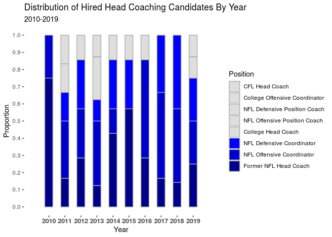

```r
Position_Ordered<-c("CFL Head Coach", "College Offensive Coordinator", "NFL Defensive Position Coach", "NFL Offensive Position Coach", "College Head Coach", "NFL Defensive Coordinator","NFL Offensive Coordinator", "Former NFL Head Coach")


Coach_Hiring_100_Percent_Stacked <- Ethics_Project_Stat_Sheet_Coaching_Hiring_Practices %>%
  mutate(Position_Before_Hiring=ordered(Position_Before_Hiring, levels=Position_Ordered))%>%    arrange(Position_Before_Hiring)%>%
  ggplot(aes(Year, fill = Position_Before_Hiring)) +
            geom_bar(position = "fill",width = .5, color = "darkgray") +
            labs(x = "Year", y = "Proportion", fill = "Position", title = "Distribution of Hired Head Coaching Candidates By Year", subtitle = "2010-2019")+
          scale_x_continuous(limits = c(2009,2020),
                    breaks = seq(2010, 2019, 1)) +
          scale_y_continuous(limits = c(0,1),
                    breaks = seq(0, 1, 0.1)) +
        scale_fill_manual(values=c("gray87","gray87","gray87","gray87","gray87","blue","blue3","blue4"))+
        theme(panel.grid.major = element_blank(), panel.grid.minor = element_blank(), panel.background = element_blank())+
  theme(axis.text.x = element_text(face = "bold",
                           size = 10, angle = 0))
Coach_Hiring_100_Percent_Stacked
```

In the past 10 years, the NFL has hired 67 new head coaches. 83.6% of the coaching hires where either Coordinators or former head coaches at the NFL Level. Teams hired 21 NFL offensive coordinators 20 former head coaches, and 15 NFL defensive coordinators over that span. The other 11 coaches were a mixture of experience levels ranging from a former CFL head coach to College head coaches to NFL position coaches. Lastly, from 2010-2019, 41 of the coaches had a offensive background while 26 of the coaches were of a defensive background. Because the league is heading toward offensive coaches, I examined the data of NFL coordinators from the last 10 years to see if minorities are represented in those coaching positions that they are more likely to be hired for NFL Head Coaching Jobs.

NFL Offense and Defense Coordinators Data

```r
Defense_Coordinator<- Ethics_Project_Stat_Sheet_Offense_Defense_Coordinator_Numbers %>%
         filter(Offense_Coordinator_Defense_Coordinator == "Defense")
Defense_Coordinator

Offense_Coordinator<- Ethics_Project_Stat_Sheet_Offense_Defense_Coordinator_Numbers %>%
         filter(Offense_Coordinator_Defense_Coordinator == "Offense")
Offense_Coordinator
```

```r
Total_Coordinator_Prop_Table_Setup<-Ethics_Project_Stat_Sheet_Offense_Defense_Coordinator_Numbers %>%
            group_by(Year, Minority) %>%
            summarize(number = n()) %>%
            spread(Year, number)
Total_Coordinator_Prop_Table_Setup

prop.table(table(Ethics_Project_Stat_Sheet_Offense_Defense_Coordinator_Numbers$Year, Ethics_Project_Stat_Sheet_Offense_Defense_Coordinator_Numbers$Minority)) %>%
  round(4)

Defense_Coordinator_Prop_Table_Setup<- Defense_Coordinator %>%
            group_by(Year, Minority) %>%
            summarize(number = n()) %>%
            spread(Year, number)
Defense_Coordinator_Prop_Table_Setup

prop.table(table(Defense_Coordinator$Year, Defense_Coordinator$Minority)) %>%
  round(4)

Offense_Coordinator_Prop_Table_Setup<- Offense_Coordinator %>%
            group_by(Year, Minority) %>%
            summarize(number = n()) %>%
            spread(Year, number)
Offense_Coordinator_Prop_Table_Setup

prop.table(table(Offense_Coordinator$Year, Offense_Coordinator$Minority)) %>%
  round(4)
```

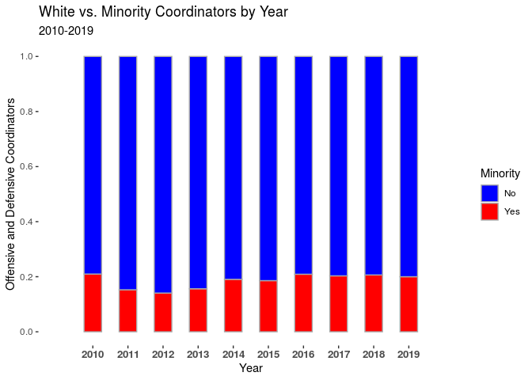

```r
Total_Bar<-Ethics_Project_Stat_Sheet_Offense_Defense_Coordinator_Numbers%>%
ggplot(aes(x=Year, fill = Minority)) +
            geom_bar(position="fill", width = .5, color = "darkgray") +
            labs(x = "Year", y = "Offensive and Defensive Coordinators", fill = "Minority", title = "White vs. Minority Coordinators by Year", subtitle = "2010-2019")+
  scale_fill_manual(values=c("blue","red"))+
        scale_x_continuous(limits = c(2009,2020),
                    breaks = seq(2010, 2019, 1)) +
         scale_y_continuous(limits = c(0,1),
                    breaks = seq(0, 1, .2)) +
        theme(panel.grid.major = element_blank(), panel.grid.minor = element_blank(), panel.background = element_blank())+
  theme(axis.text.x = element_text(face = "bold",
                           size = 10, angle = 0))
Total_Bar
```

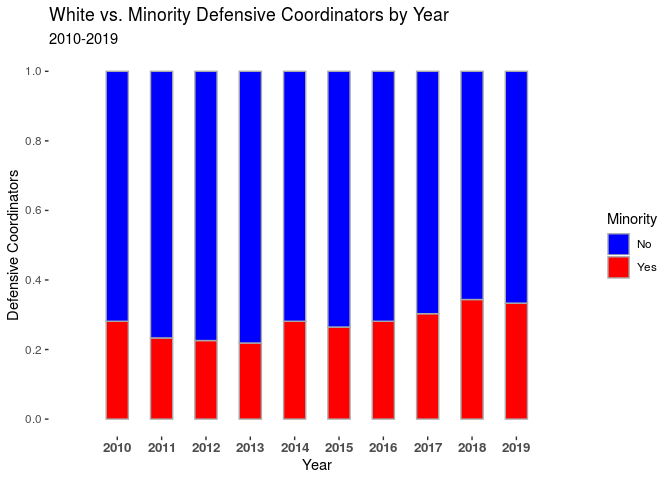

```r
Defense_Coordinator_Bar <- Defense_Coordinator%>%
  ggplot(aes(x=Year, fill = Minority)) +
            geom_bar(position="fill",width = .5, color = "darkgray") +
            labs(x = "Year", y = "Defensive Coordinators", fill = "Minority", title = "White vs. Minority Defensive Coordinators by Year", subtitle = "2010-2019")+
  scale_fill_manual(values=c("blue","red"))+
        scale_x_continuous(limits = c(2009,2020),
                    breaks = seq(2010, 2019, 1)) +
         scale_y_continuous(limits = c(0,1),
                    breaks = seq(0, 1, .2)) +
        theme(panel.grid.major = element_blank(), panel.grid.minor = element_blank(), panel.background = element_blank())+
  theme(axis.text.x = element_text(face = "bold",
                           size = 10, angle = 0))
Defense_Coordinator_Bar
```

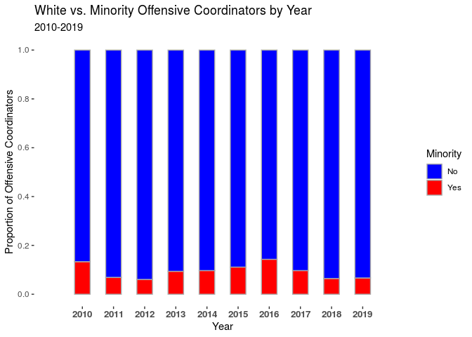

```r
Offense_Coordinator_Bar <- Offense_Coordinator%>%
  ggplot(aes(x=Year, fill = Minority)) +
            geom_bar(position="fill", width = .5, color = "darkgray") +
            labs(x = "Year", y = "Proportion of Offensive Coordinators", fill = "Minority", title = "White vs. Minority Offensive Coordinators by Year", subtitle = "2010-2019")+
  scale_fill_manual(values=c("blue","red"))+
        scale_x_continuous(limits = c(2009,2020),
                    breaks = seq(2010, 2019, 1)) +
        scale_y_continuous(limits = c(0,1),
                    breaks = seq(0, 1, .2)) +
        theme(panel.grid.major = element_blank(), panel.grid.minor = element_blank(), panel.background = element_blank())+
  theme(axis.text.x = element_text(face = "bold",
                           size = 10, angle = 0))
Offense_Coordinator_Bar
```

In the last ten years, the diversity among NFL coordinators has roughly been the same. The number of minority NFL coordinators breifly fell to 15.25% between 2011 and 2012 because of the increased hiring of minority head coaches. Between 2014 and the 2016, the number of minority coordinators increased as some of the minority head coaches were fired by their teams and a few new minority coaches were promoted to coordinator positions. From 2017 to 2019 the number of minority coaches hovered around 20%. Minority Defensive Coordinators decreased in the first half of the decade as 4 out of the six minority head coaching hires between 2010 and 2014 were defensive coordinators. Starting in 2014, more new minority coaches were promoted to defensive coordinator until a maximum of minority defensive coordinators in 2018 when 11 of the 32 defensive coordinator were a minority. Last year, one third of the league defensive coordinators were a minority. While minorities caoches are making headway to becoming defensive coordinators, the same can not be said for offensive coordinators. The number of minority offensive coordinators was greatest in 2016 when 5 out of the 35 (some offenisve coordinators were replaced mid year) offensive coordinators were minority. This has since regressed to two minority offensive coordinators in 2019 out of 30 total offensive coordinators.

Conclusion  
While the NFL was able to succeed at first when implementing the Rooney Rule in 2003 when in 2011 there were 9 minority head coaches, the number of minority head coaches has dropped off in recent years due to a lack of new coaching candidates specifically on offense. As the league has shifted to younger offensive minded coaches like Zac Taylor of the Cincinnati Bengals and Sean McVay of the Los Angles Rams, there hasn’t been enough minority coordinators within the NFL in order to sustain the hiring of minorities. One way that the NFL can build out the base of offensive minded minority coaches that fits the hiring trend in the last ten years is by incentiving former minority players to get involved in coaching. Byron Leftwich and Eric Bieniemy, the only two minority offensive coordinators in the last two years are both former players. If NFL teams focused on hiring more former players rather than hiring assistant and position coaches in their mid twenties coming out of college than the number of minorities coaches would increase because the low level entry coaching positions would not always reflect the overall population of the United States. The percentage of minorities in the US is roughly 28% and on average since 2003 minority head coaches make up roughly 18% of NFL head coaches. The average percentage of minority head coaches since 2003 is more representitive of the full US population than the NFL minority percentage of 72%. One way to solve the hiring problem would be to extend the Rooney Rule to the hiring of all coaching posistions in an effort to attract former players and give equal opportunity to minorities that are coming out of college. If I was to continue doing research, I would take a better look into the hiring practices of teams for entry level coaching positions as well as looking at the diversity of coaches in college football.

Bibliography

Fittipaldo, Ray. “Why Do NFL Coaches Rarely Rise from the Ranks of Players?” Pittsburgh Post-Gazette, Pittsburgh Post-Gazette, 22 Aug. 2014, www.post-gazette.com/sports/around-the-league-nfl/2014/08/24/Why-NFL-coaches-rarely-rise-from-ranks-of-players/stories/201408240108.

Lapchick, Richard. The 2019 Racial and Gender Report Card: National Football League. TIDES, 30 Oct. 2019, 43530132-36e9-4f52-811a-182c7a91933b.filesusr.com/ugd/3844fb_1478b405e58e42608f1ed2223437d398.pdf.

“National Football League Team Captains.” Wikipedia, Wikimedia Foundation, 17 Jan. 2020, en.wikipedia.org/wiki/National_Football_League_team_captains.

“NFL Head Coaching Hires: 2008-2012.” FOX Sports, Fox Sports, 17 Jan. 2013, www.foxsports.com/other/story/nfl-head-coaching-hires-2008-2012-011713.

“Pro Football Statistics and History.” Pro Football Reference, Sports Reference LLC, www.pro-football-reference.com/.

Rose, Donovan. NFL Head Coaches Hired During The Last 10 Years: What the Data Says. The Cauldron, 12 Jan. 2016, the-cauldron.com/nfl-head-coaches-hired-during-the-last-ten-years-a-look-at-the-data-a41e2e68a1b6.

Wyche, Steve. “Coaching Class of 2006 Still Trying to Find Its Way.” NFL.com, National Football League, 3 Aug. 2012, www.nfl.com/news/story/09000d5d80b21b0e/article/coaching-class-of-2006-still-trying-to-find-its-way.